# Exploring the US Car Market

Group 4

04/15/2026

# Introduction

Have you ever wondered why some cars cost significantly more than others? Using the **Car Features and MSRP** dataset from 1990-2017, we set out to answer our central question:

> **What factors most strongly influence a car’s price?**

# Questions

Domain Question:

What factors most strongly influence a car’s price (MSRP)?

Sub‑Questions:

1. What is the average price for two‑door vs. four‑door cars?
2. How do engine size, horsepower, or MPG relate to MSRP?
3. How does drivetrain type (FWD, RWD, AWD) influence average MSRP?
4. Which car offers the best overall value when considering MSRP, fuel efficiency, and performance?

# Why this Question ?

- Cars are a significant purchase for most people to make
- Price is misunderstood
- Help a buyer understand what drives costs to make a better decision

# Libraries

```r
library(dplyr)      # Data manipulation
library(ggplot2)    # Data visualization
library(scales)     # Formatting
```

# Dataset

- **Dataset:** Car Features and MSRP
- **Data scraped from:** Edmunds and Twitter

> Edmunds is a well-known automotive inventory and information resource — a reliable source for U.S. market vehicle data.
- **Sources**  
  https://www.kaggle.com/datasets/CooperUnion/cardataset/data  
  https://www.edmunds.com

# Inside the Dataset

```
##   Make      Model Year Engine.Fuel.Type Engine.HP Engine.Cylinders
## 1  BMW 1 Series M 2011 premium unleaded       335                6
## 2  BMW   1 Series 2011 premium unleaded       300                6
## 3  BMW   1 Series 2011 premium unleaded       300                6
## 4  BMW   1 Series 2011 premium unleaded       230                6
## 5  BMW   1 Series 2011 premium unleaded       230                6
## 6  BMW   1 Series 2012 premium unleaded       230                6
##   Transmission.Type Driven_Wheels Number.of.Doors
## 1            MANUAL           RWD               2
## 2            MANUAL           RWD               2
## 3            MANUAL           RWD               2
## 4            MANUAL           RWD               2
## 5            MANUAL           RWD               2
## 6            MANUAL           RWD               2
##                         Market.Category Vehicle.Size Vehicle.Style highway.MPG
## 1 Factory Tuner,Luxury,High-Performance      Compact         Coupe          26
## 2                    Luxury,Performance      Compact   Convertible          28
## 3               Luxury,High-Performance      Compact         Coupe          28
## 4                    Luxury,Performance      Compact         Coupe          28
## 5                                Luxury      Compact   Convertible          28
## 6                    Luxury,Performance      Compact         Coupe          28
##   city.mpg Popularity  MSRP
## 1       19       3916 46135
## 2       19       3916 40650
## 3       20       3916 36350
## 4       18       3916 29450
## 5       18       3916 34500
## 6       18       3916 31200
```

# Key Variables

- Engine.HP – Horsepower
- city.mpg / highway.MPG – Fuel efficiency
- Driven_Wheels – Drivetrain type
- Number.of.Doors – Vehicle design
- Market.Category – Luxury, performance, exotic, etc.
- MSRP – Manufacturer’s Suggested Retail Price

# Data Cleaning — Step 1: Standardizing Drivetrain Labels

```r
data <- data %>%
  mutate(Driven_Wheels = gsub("all wheel drive", "AWD", Driven_Wheels),
         Driven_Wheels = gsub("rear wheel drive", "RWD", Driven_Wheels),
         Driven_Wheels = gsub("front wheel drive", "FWD", Driven_Wheels),
         Driven_Wheels = gsub("four wheel drive", "4WD", Driven_Wheels))
```

- Standardized the Drivetrain label by their abbreviation
- Well known
- Looked better on the eye for graph

# Data Cleaning — Step 2: Fuel Type Consolidation

```r
data <- data %>%
  mutate(Engine.Fuel.Type = case_when(
    Engine.Fuel.Type == "premium unleaded (required)"    ~ "premium unleaded",
    Engine.Fuel.Type == "premium unleaded (recommended)" ~ "premium unleaded",
    Engine.Fuel.Type %in% c("flex-fuel (unleaded/E85)",
                             "flex-fuel (premium unleaded recommended/E85)",
                             "flex-fuel (premium unleaded required/E85)") ~ "Flex-Fuel",
    TRUE ~ Engine.Fuel.Type
  ))
```

- Multiple variants of the same fuel type were being treated as separate categories

# Data Cleaning — Step 3: Filtering Rare & Unknown Types

```r
data <- data %>%
  filter(!Transmission.Type %in% c("UNKNOWN", "DIRECT_DRIVE")) %>%
  filter(!Engine.Fuel.Type %in% c("", "natural gas", "electric"))
```

- Natural gas and electric vehicles follow different pricing structures than standard vehicles
- Decided to get rid of “UNKOWN” and “DIRECT_DRIVE” Transmission since it was only a hand full of rows

# Data Cleaning — Step 4: Dropping Rows with Missing Values

```r
data <- data %>%
  filter(!is.na(Number.of.Doors),
         !is.na(Engine.Cylinders),
         !is.na(Engine.HP))
```

- Rows missing horsepower, cylinders, or doors were taking out to prevent the data skew

# Data Cleaning — Step 5: Removing Outliers

```r
data <- data %>%
  filter(MSRP <= 1000000) %>%
  filter(highway.MPG <= 200)
```

- **MSRP > $1M** — We want to focus on cars less than 1 million
- **Highway MPG > 200** — a data entry error that distorts MPG visualizations

# Two doors VS Four doors

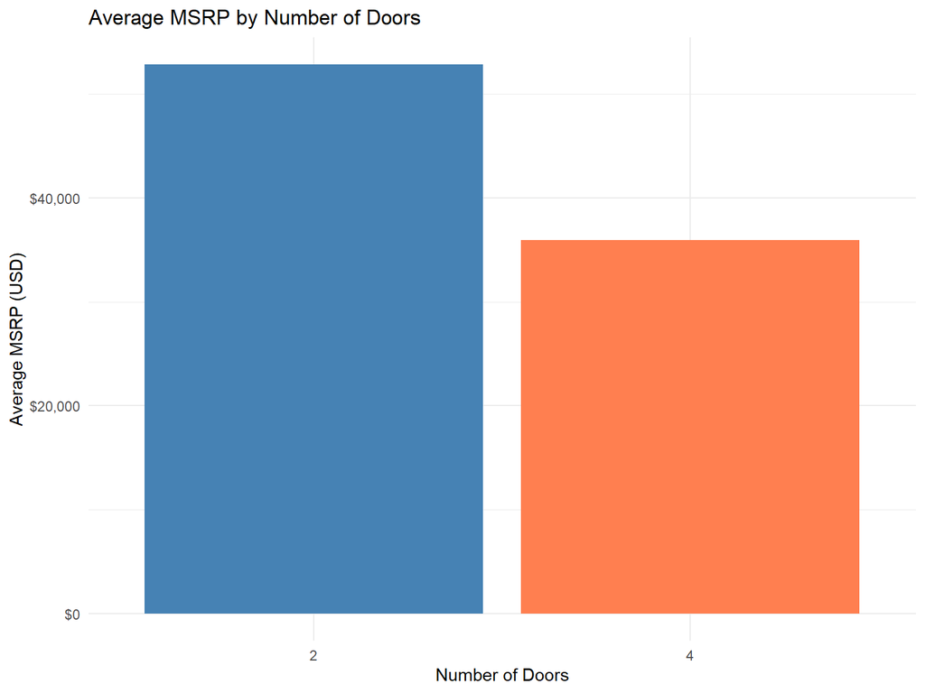

- Two‑door cars tend to have higher average MSRPs, often due to sports/performance models car.

# Average MSRP by Drivetrain type

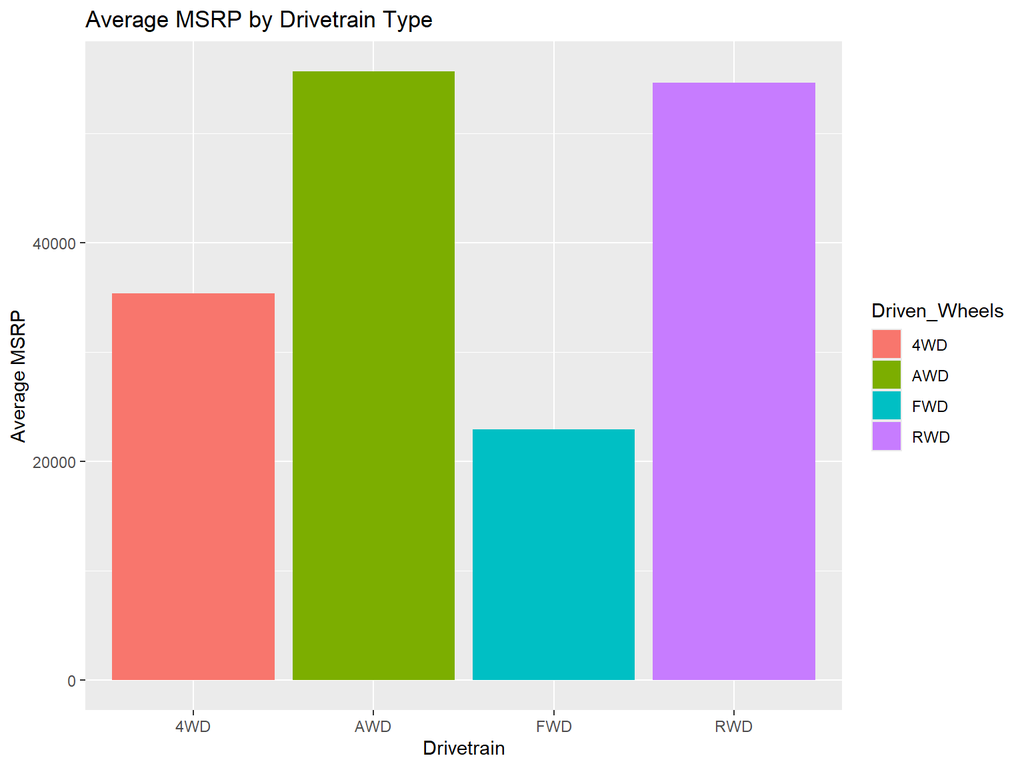

- AWD vehicles have the highest average MSRP
- FWD vehicles have the lowest

# engine size, horsepower, MPG relationship with MSRP

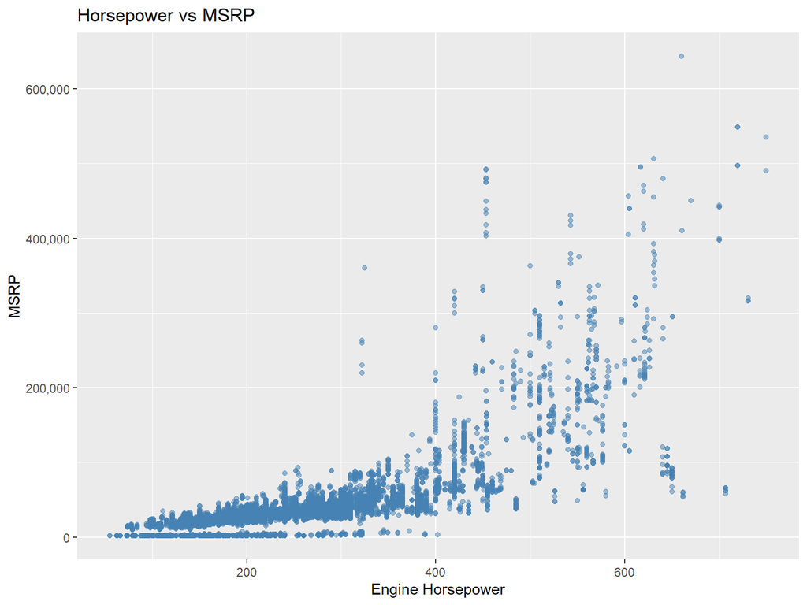

- Higher horsepower is strongly associated with higher MSRP.

# City MPG vs MSRP

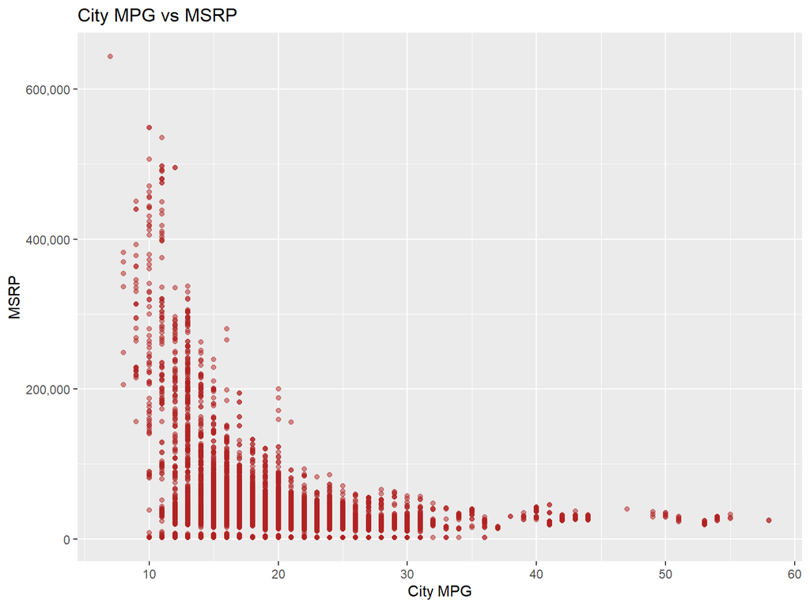

- More fuel‑efficient cars tend to be cheaper.

# Highway MPG vs MSRP

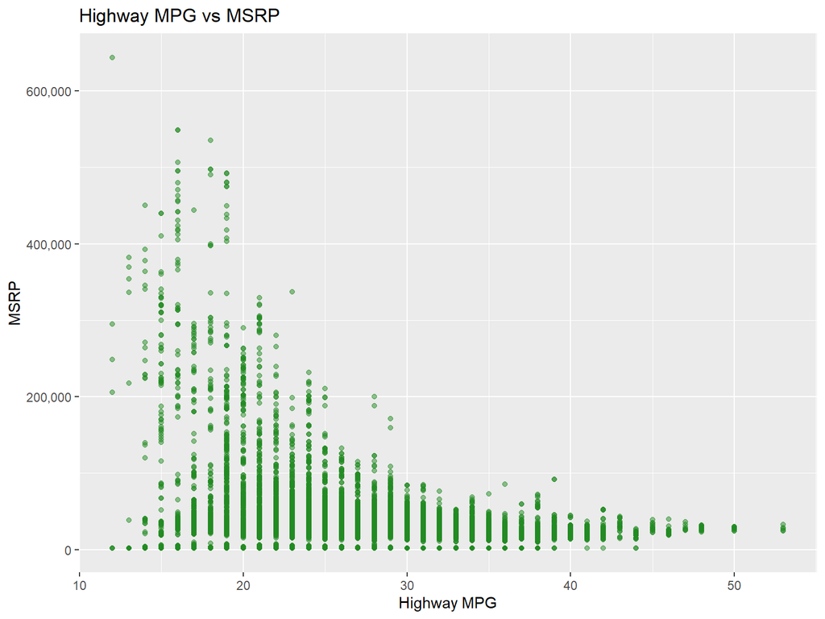

# Top 10 Best Value Car Brands Based on MSRP, City MPG, and Highway MPG

```
## # A tibble: 10 × 7
##    Make       Model          Year  MSRP city.mpg highway.MPG total_score
##    <chr>      <chr>         <int> <int>    <int>       <int>       <dbl>
##  1 Toyota     Prius          2016 24700       58          53        2.96
##  2 Honda      Accord Hybrid  2017 29605       49          47        2.63
##  3 Volkswagen Jetta Hybrid   2013 24995       42          48        2.53
##  4 Kia        Optima Hybrid  2017 25995       39          46        2.42
##  5 Ford       Fusion Hybrid  2016 25675       44          41        2.40
##  6 Hyundai    Sonata Hybrid  2017 26000       39          45        2.39
##  7 Mitsubishi Mirage         2014 13995       37          44        2.35
##  8 Lexus      CT 200h        2016 31250       43          40        2.34
##  9 Lincoln    MKZ            2015 35190       41          39        2.27
## 10 Chevrolet  Metro          1999  2000       34          42        2.26
```

# The thing is, this is a little misleading because it doesn’t tell the whole story…

### When we filter by make (and not model), I’ll show you what happens with this pie chart on the next slide.

# Nah, we’re joking—we know better than to use those “#DrShoemakerExtraPointsPlease”

### Yes, we’re desperate enough to hold you at pie chart point 😭

# Toyota and Honda form a duopoly on the chart, accounting for a mind-boggling 70% of the top 10 (kia keep up lil bro)

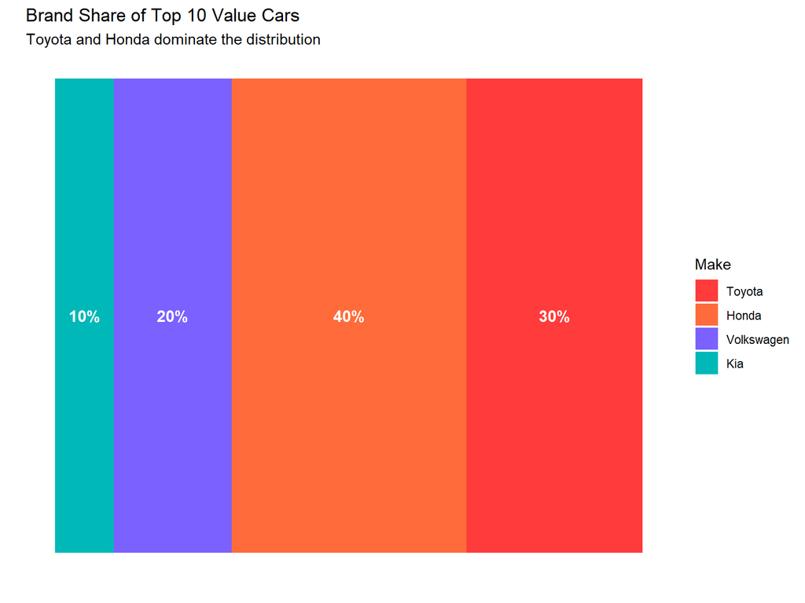

# Summary

- Price is strongly influenced by **horsepower and drivetrain type**
- **Higher horsepower → higher MSRP**, while **higher MPG → lower MSRP**
- **AWD vehicles** tend to be the most expensive, while **FWD are the cheapest**
- When ranking value, **Toyota and Honda dominate**, making up **70% of the top 10**
- Overall, the best value cars balance **low price, high fuel efficiency, and solid performance**